# Detección GBM - analisis de los factores de riesgo

# Análisis del estado del paciente (vivo/muerto)

Se analiza los valores de las variables dependiendo del estado del paciente, si está vivo o muerto, y la relación que tienen con la variable de clase.

```r
dataset_vital_status <- dataset_risk[, -c(life_expectancy_index, cause_of_death_index)]

class_val_index <- which(names(dataset_vital_status) == 'vital_status', arr.ind = TRUE)
numeric_var_indexes_vital <- c(which(sapply(dataset_vital_status, class) == 'numeric', arr.ind = TRUE), which(sapply(dataset_vital_status, class) == 'integer', arr.ind = TRUE))
non_numeric_var_indexes_vital <- which(sapply(dataset_vital_status, class) == 'factor', arr.ind = TRUE)
non_numeric_var_indexes_vital <- non_numeric_var_indexes_vital[-which(non_numeric_var_indexes_vital ==  class_val_index, arr.ind = TRUE)]

summary(dataset_vital_status)
```

```
      age                                                                                                      alcohol_consumption      bmi             case_id       gender
 Min.   :24.00   Alcohol consumption equal to or less than 2 drinks per day for men and 1 drink or less per day for women:29       Min.   : 1.84   C3L-00016:  1   Female:60
 1st Qu.:50.00   Alcohol consumption more than 2 drinks per day for men and more than 1 drink per day for women          : 9       1st Qu.:22.61   C3L-00019:  1   Male  :98
 Median :60.00   Consumed alcohol in the past, but currently a non-drinker                                               : 5       Median :25.14   C3L-00265:  1
 Mean   :58.48   Lifelong non-drinker                                                                                    :90       Mean   :25.71   C3L-00278:  1
 3rd Qu.:68.00   NA's                                                                                                    :25       3rd Qu.:28.06   C3L-00349:  1
 Max.   :88.00                                                                                                                     Max.   :46.97   C3L-00424:  1
                                                                                                                                                   (Other)  :152
  height_in_cm   number_of_pack_years_smoked                                                     tobacco_smoking_history                           tumor_site tumor_size_in_cm
 Min.   :150.0   Min.   : 0.000              Current reformed smoker within past 15 years                    : 3         Temporal Lobe                  :46   Min.   :1.000
 1st Qu.:165.0   1st Qu.: 0.000              Current reformed smoker, more than 15 years                     :13         Frontal Lobe                   :40   1st Qu.:3.500
 Median :172.0   Median : 0.000              Current reformed smoker, years unknown                          : 1         Parietal Lobe                  :21   Median :4.600
 Mean   :171.5   Mean   : 6.441              Current smoker: Includes daily and non-daily smokers            :25         Occipital Lobe                 :10   Mean   :4.519
 3rd Qu.:178.0   3rd Qu.: 0.000              Lifelong non-smoker: Less than 100 cigarettes smoked in lifetime:99         Temporal Lobe and Parietal Lobe: 4   3rd Qu.:5.500
 Max.   :198.0   Max.   :66.000              NA's                                                            :17         (Other)                        :16   Max.   :8.500
 NA's   :1       NA's   :30                                                                                              NA's                           :21   NA's   :1
  weight_in_kg    years_high_alcohol_quantity_consumed time_monitored     vital_status
 Min.   : 29.00   Min.   : 0.000                       Min.   :   0.0   Deceased:94
 1st Qu.: 66.00   1st Qu.: 0.000                       1st Qu.: 205.2   Living  :64
 Median : 75.00   Median : 0.000                       Median : 386.0
 Mean   : 76.42   Mean   : 1.365                       Mean   : 445.5
 3rd Qu.: 87.00   3rd Qu.: 0.000                       3rd Qu.: 715.0
 Max.   :166.00   Max.   :50.000                       Max.   :1115.0
                  NA's   :32
```

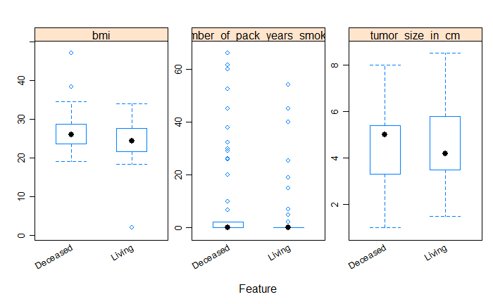

```r
# Boxplots para las variables numéricas
featurePlot(x=dataset_vital_status[, numeric_var_indexes_vital[1:3]],
            y=dataset_vital_status$vital_status, plot="box",
            scales = list(y = list(relation="free"),
                          x = list(rot = 30)),
            layout = c(3, 1))
```

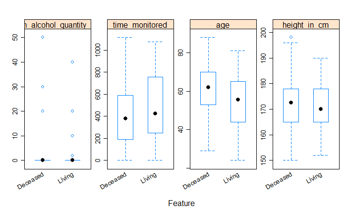

```r
featurePlot(x=dataset_vital_status[, numeric_var_indexes_vital[4:7]],
            y=dataset_vital_status$vital_status, plot="box",
            scales = list(y = list(relation="free"),
                          x = list(rot = 30)),
            layout = c(4, 1))
```

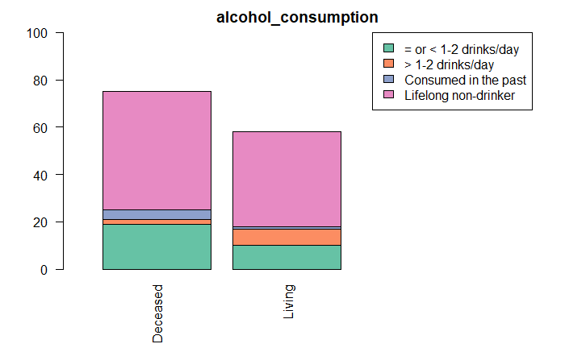

```r
#Barplots
barplot(table(dataset_vital_status[, c(non_numeric_var_indexes_vital[1], class_val_index)]),
        main = names(dataset_vital_status)[non_numeric_var_indexes_vital[1]],
        col = brewer.pal(n = 4, name = "Set2"),
        las = 2,
        xlim = c(0, 4),
        ylim = c(0, 100),
        legend.text = TRUE,
        args.legend = list(x = "topright",
                           legend = c("= or < 1-2 drinks/day",
                                      "> 1-2 drinks/day", "Consumed in the past", "Lifelong non-drinker"),
                           fill = brewer.pal(n = 4, name = "Set2"),
                           ncol = 1))
```

```
minimal value for n is 3, returning requested palette with 3 different levels
```

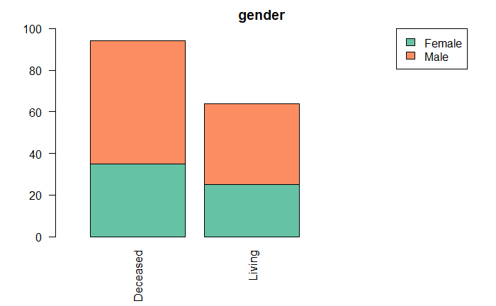

```r
barplot(table(dataset_vital_status[, c(non_numeric_var_indexes_vital[3], class_val_index)]),
        main = names(dataset_vital_status)[non_numeric_var_indexes_vital[3]],
        col = brewer.pal(n = 2, name = "Set2"),
        las = 2,
        xlim = c(0, 4),
        ylim = c(0, 100),
        legend.text = TRUE,
        args.legend = list(x = "topright",
                           legend = c("Female", "Male"),
                           fill = brewer.pal(n = 2, name = "Set2"),
                           ncol = 1))
```

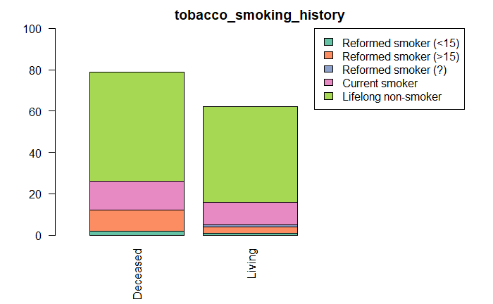

```r
barplot(table(dataset_vital_status[, c(non_numeric_var_indexes_vital[4], class_val_index)]),
        main = names(dataset_vital_status)[non_numeric_var_indexes_vital[4]],
        col = brewer.pal(n = 5, name = "Set2"),
        las = 2,
        xlim = c(0, 4),
        ylim = c(0, 100),
        legend.text = TRUE,
        args.legend = list(x = "topright",
                           legend = c("Reformed smoker (<15)", "Reformed smoker (>15)", "Reformed smoker (?)",
                                      "Current smoker", "Lifelong non-smoker"),
                           fill = brewer.pal(n = 5, name = "Set2"),
                           ncol = 1))
```

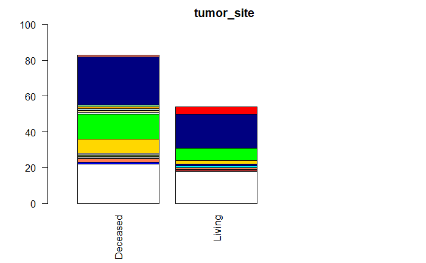

```r
barplot(table(dataset_vital_status[, c(non_numeric_var_indexes_vital[5], class_val_index)]),
        main = names(dataset_vital_status)[non_numeric_var_indexes_vital[5]],
        col = c("white", "blue", "brown", "coral", "cyan", "darkgray", "darkblue", "darkolivegreen", "gray", "gold",
                "green", "lavender", "khaki", "lightblue", "orange", "palegreen", "navy", "red", "salmon", "purple",
                "yellow", "turquoise"),
        las = 2,
        xlim = c(0, 4),
        ylim = c(0, 100))
```

```r
# Class imbalance
cbind(Label_freq=table(dataset_vital_status$vital_status), Label_percent=prop.table(table(dataset_vital_status$vital_status))*100)
```

```
         Label_freq Label_percent
Deceased         94      59.49367
Living           64      40.50633
```

Con los datos obtenidos se concluyen los siguientes puntos.

- Se observa que el dataset está más o menos balanceado (40.5% de pacientes vivos y 59.5% muertos).
- Analizando los boxplots y los barplots creados, no se puede determinar una separación clara entre las distintas variables de clase. La realidad es que hay ciertas tendencias, por ejemplo, parece que la mayoría de los que han muerto tenian un tamaño de tumor algo más alto como mediana, o que hay más supervivientes en edades menos avanzadas, pero no se observa que ninguna variable sea determinante para predicción de el estado del paciente.